# Small Test Grid Search Solution

This is the example vignette for function: [snw_vfi_main_grid_search](https://github.com/FanWangEcon/PrjOptiSNW/tree/master/PrjOptiSNW/svalpol/snw_vfi_main_grid_search.m) from the [PrjOptiSNW Package](https://fanwangecon.github.io/PrjOptiSNW/). This function solves for policy function using grid search. Small Solution Analysis. Small Solution Analysis, husband 5 shocks, wife 1 shocks.

## Test SNW_VFI_MAIN_GRID_SEARCH Defaults Small

Call the function with defaults parameters.

```matlab
mp_param = snw_mp_param('default_small');
[V_VFI,ap_VFI,cons_VFI,mp_valpol_more] = snw_vfi_main_grid_search(mp_param);
```

SNW_VFI_MAIN_GRID_SEARCH: Finished Age Group:18 of 18 SNW_VFI_MAIN_GRID_SEARCH: Finished Age Group:17 of 18 SNW_VFI_MAIN_GRID_SEARCH: Finished Age Group:16 of 18 SNW_VFI_MAIN_GRID_SEARCH: Finished Age Group:15 of 18 SNW_VFI_MAIN_GRID_SEARCH: Finished Age Group:14 of 18 SNW_VFI_MAIN_GRID_SEARCH: Finished Age Group:13 of 18 SNW_VFI_MAIN_GRID_SEARCH: Finished Age Group:12 of 18 SNW_VFI_MAIN_GRID_SEARCH: Finished Age Group:11 of 18 SNW_VFI_MAIN_GRID_SEARCH: Finished Age Group:10 of 18 SNW_VFI_MAIN_GRID_SEARCH: Finished Age Group:9 of 18 SNW_VFI_MAIN_GRID_SEARCH: Finished Age Group:8 of 18 SNW_VFI_MAIN_GRID_SEARCH: Finished Age Group:7 of 18 SNW_VFI_MAIN_GRID_SEARCH: Finished Age Group:6 of 18 SNW_VFI_MAIN_GRID_SEARCH: Finished Age Group:5 of 18 SNW_VFI_MAIN_GRID_SEARCH: Finished Age Group:4 of 18 SNW_VFI_MAIN_GRID_SEARCH: Finished Age Group:3 of 18 SNW_VFI_MAIN_GRID_SEARCH: Finished Age Group:2 of 18 SNW_VFI_MAIN_GRID_SEARCH: Finished Age Group:1 of 18 Elapsed time is 6.771761 seconds. Completed SNW_VFI_MAIN_GRID_SEARCH;SNW_MP_PARAM=default_small;SNW_MP_CONTROL=default_base

## Small Param Results Define Frames

Define the matrix dimensions names and dimension vector values. Policy and Value Functions share the same ND dimensional structure.

```matlab
% Grids:
age_grid = [19, 22:5:97, 100];
agrid = mp_param('agrid')';
eta_H_grid = mp_param('eta_H_grid')';
eta_S_grid = mp_param('eta_S_grid')';
ar_st_eta_HS_grid = string(cellstr([num2str(eta_H_grid', 'hz=%3.2f;'), num2str(eta_S_grid', 'wz=%3.2f')]));
edu_grid = [0,1];
marry_grid = [0,1];
kids_grid = (1:1:mp_param('n_kidsgrid'))';
% NaN(n_jgrid,n_agrid,n_etagrid,n_educgrid,n_marriedgrid,n_kidsgrid);
cl_mp_datasetdesc = {};
cl_mp_datasetdesc{1} = containers.Map({'name', 'labval'}, {'age', age_grid});
cl_mp_datasetdesc{2} = containers.Map({'name', 'labval'}, {'savings', agrid});
cl_mp_datasetdesc{3} = containers.Map({'name', 'labval'}, {'Hshock', eta_H_grid});
cl_mp_datasetdesc{4} = containers.Map({'name', 'labval'}, {'edu', edu_grid});
cl_mp_datasetdesc{5} = containers.Map({'name', 'labval'}, {'marry', marry_grid});
cl_mp_datasetdesc{6} = containers.Map({'name', 'labval'}, {'kids', kids_grid});
```

## Analyze Savings and Shocks

First, analyze Savings Levels and Shocks, Aggregate Over All Others, and do various other calculations.

```matlab
% Generate some Data
mp_support_graph = containers.Map('KeyType', 'char', 'ValueType', 'any');
mp_support_graph('cl_st_xtitle') = {'Savings States, a'};
mp_support_graph('st_legend_loc') = 'best';
mp_support_graph('bl_graph_logy') = true; % do not log
```

MEAN(VAL(A,Z)), MEAN(AP(A,Z)), MEAN(C(A,Z))

Tabulate value and policies along savings and shocks:

```matlab
% Set
% NaN(n_jgrid,n_agrid,n_etagrid,n_educgrid,n_marriedgrid,n_kidsgrid);
ar_permute = [1,4,5,6,3,2];
% Value Function
tb_az_v = ff_summ_nd_array("MEAN(VAL(A,Z))", V_VFI, true, ["mean"], 4, 1, cl_mp_datasetdesc, ar_permute);
```

xxx MEAN(VAL(A,Z)) xxxxxxxxxxxxxxxxxxxxxxxxxxx **group** **savings** **mean_Hshock__1_8395** **mean_Hshock__0_91976** **mean_Hshock_0** **mean_Hshock_0_91976** **mean_Hshock_1_8395** **_____** **_________** **___________________** **____________________** **_____________** **___________________** **__________________** 1 0 -17.723 -9.4806 -4.7079 -1.8282 -0.2506 2 0.0097656 -17.287 -9.3335 -4.6223 -1.7575 -0.18381 3 0.078125 -15.289 -8.5102 -4.1607 -1.3897 0.15884 4 0.26367 -12.169 -7.0906 -3.3823 -0.82837 0.65605 5 0.625 -8.7667 -5.3975 -2.4071 -0.24676 1.1271 6 1.2207 -5.7445 -3.6744 -1.4216 0.29453 1.5213 7 2.1094 -3.3257 -2.112 -0.53821 0.80697 1.8359 8 3.3496 -1.5195 -0.81731 0.22515 1.2742 2.0887 9 5 -0.20516 0.20391 0.87016 1.6615 2.3015 10 7.1191 0.74607 0.98431 1.4069 1.9813 2.4914 11 9.7656 1.4347 1.5779 1.8454 2.2495 2.6581 12 12.998 1.9367 2.0246 2.1961 2.4767 2.8 13 16.875 2.3099 2.364 2.476 2.6699 2.9198 14 21.455 2.5887 2.6239 2.6967 2.8321 3.0216 15 26.797 2.7998 2.8231 2.8727 2.9673 3.1096 16 32.959 2.963 2.9785 3.0123 3.0792 3.186 17 40 3.0902 3.1009 3.1242 3.1721 3.2523 18 47.979 3.1902 3.1978 3.2144 3.2489 3.3096 19 56.953 3.27 3.2754 3.2875 3.3128 3.3588 20 66.982 3.3345 3.3384 3.3471 3.3661 3.4012 21 78.125 3.3871 3.3899 3.3964 3.4105 3.4375 22 90.439 3.4301 3.4323 3.4372 3.4479 3.4688 23 103.98 3.4658 3.4674 3.4712 3.4794 3.4957 24 118.82 3.4957 3.4969 3.4998 3.5062 3.519 25 135 3.5208 3.5218 3.524 3.5289 3.5391

```matlab
% Aprime Choice
tb_az_ap = ff_summ_nd_array("MEAN(AP(A,Z))", ap_VFI, true, ["mean"], 4, 1, cl_mp_datasetdesc, ar_permute);
```

xxx MEAN(AP(A,Z)) xxxxxxxxxxxxxxxxxxxxxxxxxxx **group** **savings** **mean_Hshock__1_8395** **mean_Hshock__0_91976** **mean_Hshock_0** **mean_Hshock_0_91976** **mean_Hshock_1_8395** **_____** **_________** **___________________** **____________________** **_____________** **___________________** **__________________** 1 0 1 1.1435 1.5972 2.5926 4.162 2 0.0097656 1.0463 1.213 1.6574 2.6157 4.1667 3 0.078125 1.8009 2.0093 2.1991 2.875 4.3056 4 0.26367 2.9491 3.0648 3.2454 3.6204 4.7315 5 0.625 4.0602 4.1806 4.2546 4.5417 5.4074 6 1.2207 5.1481 5.2454 5.2731 5.4074 6.0231 7 2.1094 6.1389 6.213 6.25 6.2593 6.7731 8 3.3496 7.0556 7.1019 7.1713 7.162 7.5648 9 5 7.9537 7.9815 8.0556 8.0787 8.3426 10 7.1191 8.8611 8.8889 8.9398 9.0093 9.0926 11 9.7656 9.7824 9.7963 9.8519 9.9259 9.9444 12 12.998 10.606 10.63 10.648 10.731 10.787 13 16.875 11.481 11.491 11.537 11.597 11.685 14 21.455 12.407 12.407 12.431 12.491 12.597 15 26.797 13.287 13.301 13.306 13.356 13.463 16 32.959 14.13 14.13 14.167 14.199 14.296 17 40 14.981 14.981 14.991 15.032 15.125 18 47.979 15.88 15.88 15.884 15.921 15.995 19 56.953 16.75 16.773 16.782 16.796 16.87 20 66.982 17.681 17.685 17.699 17.722 17.787 21 78.125 18.495 18.5 18.509 18.551 18.602 22 90.439 19.338 19.338 19.352 19.37 19.449 23 103.98 20.25 20.264 20.269 20.278 20.352 24 118.82 21.097 21.097 21.13 21.144 21.194 25 135 21.963 21.968 21.977 21.995 22.046

```matlab
% Consumption Choices
tb_az_c = ff_summ_nd_array("MEAN(C(A,Z))", cons_VFI, true, ["mean"], 4, 1, cl_mp_datasetdesc, ar_permute);
```

xxx MEAN(C(A,Z)) xxxxxxxxxxxxxxxxxxxxxxxxxxx **group** **savings** **mean_Hshock__1_8395** **mean_Hshock__0_91976** **mean_Hshock_0** **mean_Hshock_0_91976** **mean_Hshock_1_8395** **_____** **_________** **___________________** **____________________** **_____________** **___________________** **__________________** 1 0 0.30277 0.43205 0.70498 1.2497 2.3063 2 0.0097656 0.31384 0.44176 0.71311 1.2574 2.3169 3 0.078125 0.38061 0.49936 0.768 1.3132 2.3716 4 0.26367 0.50208 0.6111 0.86902 1.423 2.516 5 0.625 0.67677 0.76238 1.0363 1.5854 2.6625 6 1.2207 0.89732 0.96685 1.2492 1.8485 2.9934 7 2.1094 1.2189 1.2789 1.543 2.2417 3.35 8 3.3496 1.6892 1.7561 1.9651 2.6933 3.7969 9 5 2.3251 2.4024 2.5736 3.2505 4.4588 10 7.1191 3.1269 3.1903 3.3745 3.9408 5.4846 11 9.7656 4.0839 4.1689 4.3128 4.829 6.5432 12 12.998 5.4106 5.457 5.6873 6.1291 7.7117 13 16.875 6.9612 7.0462 7.1563 7.6332 9.0535 14 21.455 8.5924 8.7131 8.8962 9.3301 10.603 15 26.797 10.6 10.647 10.911 11.348 12.539 16 32.959 13.149 13.269 13.33 13.839 14.999 17 40 16.034 16.154 16.378 16.792 17.899 18 47.979 18.971 19.092 19.343 19.756 20.923 19 56.953 22.573 22.485 22.69 23.274 24.367 20 66.982 26.089 26.168 26.322 26.797 27.905 21 78.125 30.843 30.917 31.101 31.36 32.556 22 90.439 35.929 36.049 36.177 36.667 37.477 23 103.98 40.986 40.918 41.144 41.731 42.514 24 118.82 47.072 47.192 47.018 47.525 48.539 25 135 53.493 53.538 53.682 54.096 55.054

Graph Mean Values:

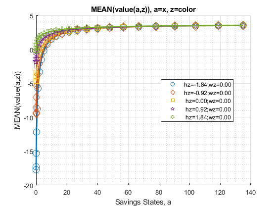

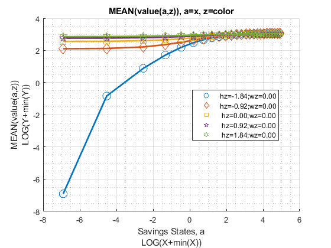

```matlab
mp_support_graph('cl_st_graph_title') = {'MEAN(value(a,z)), a=x, z=color'};
mp_support_graph('cl_st_ytitle') = {'MEAN(value(a,z))'};
ff_graph_grid((tb_az_v{1:end, 3:end})', ar_st_eta_HS_grid, agrid, mp_support_graph);
```

Graph Mean Savings Choices:

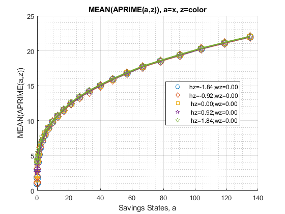

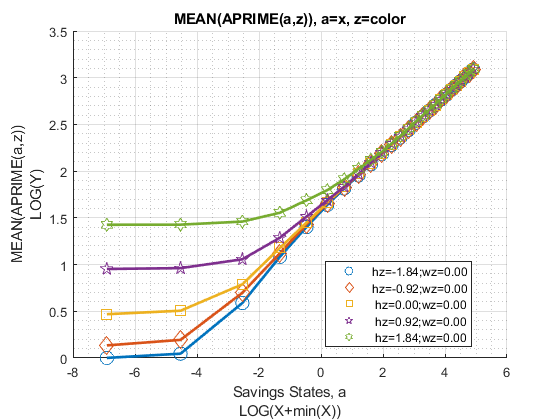

```matlab
mp_support_graph('cl_st_graph_title') = {'MEAN(APRIME(a,z)), a=x, z=color'};
mp_support_graph('cl_st_ytitle') = {'MEAN(APRIME(a,z))'};
ff_graph_grid((tb_az_ap{1:end, 3:end})', ar_st_eta_HS_grid, agrid, mp_support_graph);
```

Graph Mean Consumption:

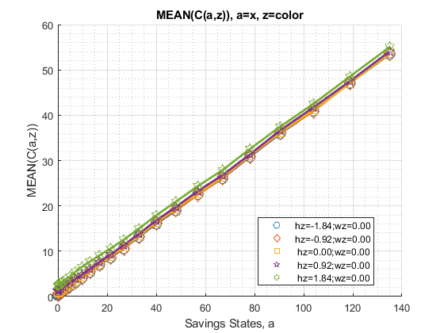

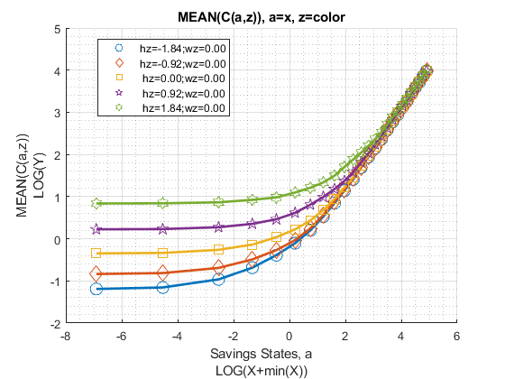

```matlab
mp_support_graph('cl_st_graph_title') = {'MEAN(C(a,z)), a=x, z=color'};
mp_support_graph('cl_st_ytitle') = {'MEAN(C(a,z))'};
ff_graph_grid((tb_az_c{1:end, 3:end})', ar_st_eta_HS_grid, agrid, mp_support_graph);
```

## Analyze Kids and Marriage and Age

Aggregating over education, savings, and shocks, what are the differential effects of Marriage and Age.

```matlab
% Generate some Data
mp_support_graph = containers.Map('KeyType', 'char', 'ValueType', 'any');
ar_row_grid = ["k0M0", "K1M0", "K2M0", "k0M1", "K1M1", "K2M1"];
mp_support_graph('cl_st_xtitle') = {'Age'};
mp_support_graph('st_legend_loc') = 'best';
mp_support_graph('bl_graph_logy') = true; % do not log
mp_support_graph('st_rounding') = '6.2f'; % format shock legend
mp_support_graph('cl_scatter_shapes') = { 'o', 'd' ,'s', 'o', 'd', 's'};
mp_support_graph('cl_colors') = {'red', 'red', 'red', 'blue', 'blue', 'blue'};
```

MEAN(VAL(KM,J)), MEAN(AP(KM,J)), MEAN(C(KM,J))

Tabulate value and policies:

```matlab
% Set
% NaN(n_jgrid,n_agrid,n_etagrid,n_educgrid,n_marriedgrid,n_kidsgrid);
ar_permute = [2,3,4,1,6,5];
% Value Function
tb_az_v = ff_summ_nd_array("MEAN(VAL(KM,J))", V_VFI, true, ["mean"], 3, 1, cl_mp_datasetdesc, ar_permute);
```

xxx MEAN(VAL(KM,J)) xxxxxxxxxxxxxxxxxxxxxxxxxxx **group** **kids** **marry** **mean_age_19** **mean_age_22** **mean_age_27** **mean_age_32** **mean_age_37** **mean_age_42** **mean_age_47** **mean_age_52** **mean_age_57** **mean_age_62** **mean_age_67** **mean_age_72** **mean_age_77** **mean_age_82** **mean_age_87** **mean_age_92** **mean_age_97** **mean_age_100** **_____** **____** **_____** **___________** **___________** **___________** **___________** **___________** **___________** **___________** **___________** **___________** **___________** **___________** **___________** **___________** **___________** **___________** **___________** **___________** **____________** 1 1 0 1.402 1.6857 1.8728 1.9257 1.894 1.8046 1.6765 1.521 1.3445 1.1558 0.9567 0.71704 0.023702 0.12932 0.1935 0.2324 0.27 0.31342 2 2 0 -0.12483 0.36646 0.7436 0.9457 1.0402 1.0532 1.0089 0.92218 0.80354 0.66431 0.51986 0.30396 -0.48224 -0.32022 -0.20441 -0.12064 -0.046895 0.029025 3 3 0 -0.89708 -0.41863 -0.032067 0.18508 0.29597 0.33212 0.31608 0.26209 0.18086 0.082298 -0.023782 -0.21383 -1.1266 -0.8627 -0.64664 -0.47726 -0.33746 -0.1892 4 1 1 1.967 2.1822 2.3218 2.3638 2.3393 2.2644 2.1513 2.0064 1.832 1.6337 1.4095 1.1397 0.66739 0.6334 0.58559 0.54789 0.52562 0.51422 5 2 1 0.96762 1.2863 1.5349 1.6741 1.739 1.7415 1.6951 1.6078 1.4838 1.329 1.1418 0.90125 0.43962 0.438 0.42018 0.40748 0.40166 0.40636 6 3 1 0.51874 0.8123 1.0493 1.1855 1.2514 1.2646 1.2376 1.1769 1.0862 0.96852 0.81856 0.61623 0.17742 0.22234 0.24837 0.27222 0.29305 0.32582

```matlab
% Aprime Choice
tb_az_ap = ff_summ_nd_array("MEAN(AP(KM,J))", ap_VFI, true, ["mean"], 3, 1, cl_mp_datasetdesc, ar_permute);
```

xxx MEAN(AP(KM,J)) xxxxxxxxxxxxxxxxxxxxxxxxxxx **group** **kids** **marry** **mean_age_19** **mean_age_22** **mean_age_27** **mean_age_32** **mean_age_37** **mean_age_42** **mean_age_47** **mean_age_52** **mean_age_57** **mean_age_62** **mean_age_67** **mean_age_72** **mean_age_77** **mean_age_82** **mean_age_87** **mean_age_92** **mean_age_97** **mean_age_100** **_____** **____** **_____** **___________** **___________** **___________** **___________** **___________** **___________** **___________** **___________** **___________** **___________** **___________** **___________** **___________** **___________** **___________** **___________** **___________** **____________** 1 1 0 12.948 12.924 13.052 13.152 13.224 13.264 13.26 13.144 13.036 12.944 12.848 12.716 11.76 11.48 10.98 10.22 8.98 1 2 2 0 12.924 12.88 13.008 13.096 13.16 13.108 13 12.916 12.828 12.768 12.708 12.532 11.68 11.32 10.8 9.96 8.78 1 3 3 0 12.86 12.848 12.972 13.084 13.108 13.024 12.94 12.86 12.792 12.736 12.692 12.516 11.64 11.32 10.8 9.98 8.82 1 4 1 1 12.86 12.856 12.972 13.076 13.14 13.184 13.156 13.048 12.948 12.84 12.78 12.728 11.76 11.4 10.88 10 8.8 1 5 2 1 12.876 12.82 12.956 13.028 13.1 13.124 13.012 12.888 12.784 12.696 12.68 12.58 11.64 11.32 10.7 9.92 8.64 1 6 3 1 12.804 12.784 12.912 12.984 13.06 13.036 12.92 12.812 12.716 12.644 12.644 12.524 11.66 11.28 10.7 9.92 8.64 1

```matlab
% Consumption Choices
tb_az_c = ff_summ_nd_array("MEAN(C(KM,J))", cons_VFI, true, ["mean"], 3, 1, cl_mp_datasetdesc, ar_permute);
```

xxx MEAN(C(KM,J)) xxxxxxxxxxxxxxxxxxxxxxxxxxx **group** **kids** **marry** **mean_age_19** **mean_age_22** **mean_age_27** **mean_age_32** **mean_age_37** **mean_age_42** **mean_age_47** **mean_age_52** **mean_age_57** **mean_age_62** **mean_age_67** **mean_age_72** **mean_age_77** **mean_age_82** **mean_age_87** **mean_age_92** **mean_age_97** **mean_age_100** **_____** **____** **_____** **___________** **___________** **___________** **___________** **___________** **___________** **___________** **___________** **___________** **___________** **___________** **___________** **___________** **___________** **___________** **___________** **___________** **____________** 1 1 0 6.6347 6.7441 6.9773 7.1425 7.2307 7.2843 7.9778 9.774 10.91 11.532 11.822 12.591 14.484 16.598 20.123 24.389 29.942 41.087 2 2 0 6.6476 6.7581 6.9904 7.1656 7.2723 8.8488 10.314 11.204 11.744 11.996 12.11 14.207 15.012 17.933 21.133 25.463 30.711 41.087 3 3 0 6.6679 6.7696 7.0001 7.1694 7.8468 9.5068 10.698 11.387 11.816 12.031 12.411 14.361 15.226 17.933 21.133 25.34 30.698 41.087 4 1 1 6.885 7.0096 7.2673 7.4584 7.5792 7.6332 8.5309 10.294 11.362 12.04 12.305 13.082 14.784 17.354 20.535 24.838 30.413 41.428 5 2 1 6.856 6.987 7.2319 7.4245 7.5481 7.8087 9.6961 11.1 11.855 12.287 12.414 13.963 15.314 17.886 21.524 25.522 31.072 41.43 6 3 1 6.8672 6.9855 7.2175 7.4148 7.5346 8.6883 10.344 11.392 12.015 12.358 12.399 14.136 15.326 18.258 21.536 25.535 31.085 41.443

Graph Mean Values:

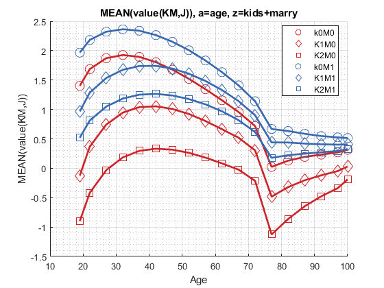

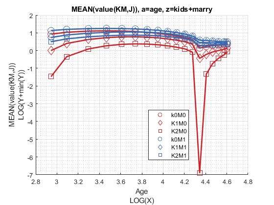

```matlab
mp_support_graph('cl_st_graph_title') = {'MEAN(value(KM,J)), a=age, z=kids+marry'};
mp_support_graph('cl_st_ytitle') = {'MEAN(value(KM,J))'};
ff_graph_grid((tb_az_v{1:end, 4:end}), ar_row_grid, age_grid, mp_support_graph);
```

Graph Mean Savings Choices:

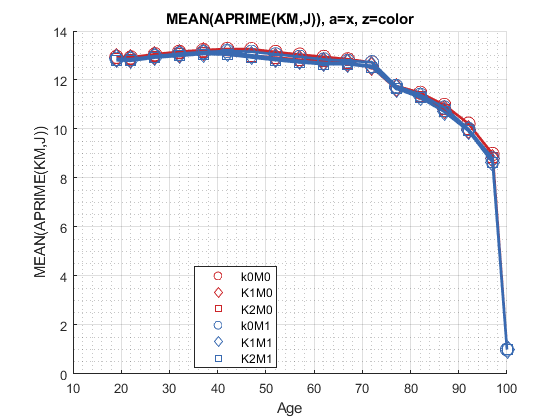

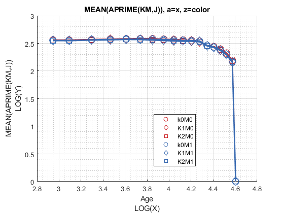

```matlab
mp_support_graph('cl_st_graph_title') = {'MEAN(APRIME(KM,J)), a=x, z=color'};
mp_support_graph('cl_st_ytitle') = {'MEAN(APRIME(KM,J))'};
ff_graph_grid((tb_az_ap{1:end, 4:end}), ar_row_grid, age_grid, mp_support_graph);
```

Graph Mean Consumption:

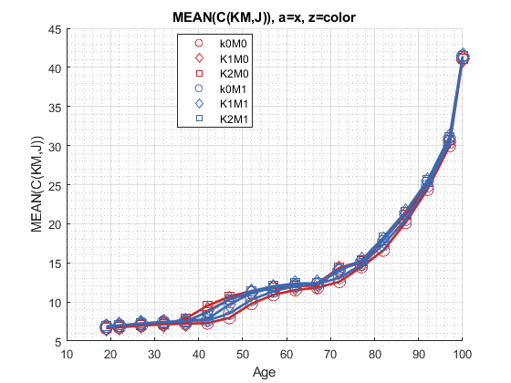

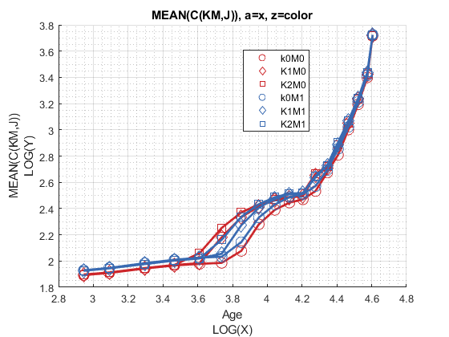

```matlab
mp_support_graph('cl_st_graph_title') = {'MEAN(C(KM,J)), a=x, z=color'};
mp_support_graph('cl_st_ytitle') = {'MEAN(C(KM,J))'};
ff_graph_grid((tb_az_c{1:end, 4:end}), ar_row_grid, age_grid, mp_support_graph);
```

## Analyze Education and Marriage and Age

```matlab
% Generate some Data
mp_support_graph = containers.Map('KeyType', 'char', 'ValueType', 'any');
ar_row_grid = ["E0M0", "E1M0", "E0M1", "E1M1"];
mp_support_graph('cl_st_xtitle') = {'Age'};
mp_support_graph('st_legend_loc') = 'best';
mp_support_graph('bl_graph_logy') = true; % do not log
mp_support_graph('st_rounding') = '6.2f'; % format shock legend
mp_support_graph('cl_scatter_shapes') = {'*', 'p', '*','p' };
mp_support_graph('cl_colors') = {'red', 'red', 'blue', 'blue'};
```

MEAN(VAL(EKM,J)), MEAN(AP(EKM,J)), MEAN(C(EKM,J))

Tabulate value and policies:

```matlab
% Set
% NaN(n_jgrid,n_agrid,n_etagrid,n_educgrid,n_marriedgrid,n_kidsgrid);
ar_permute = [2,3,6,1,4,5];
% Value Function
tb_az_v = ff_summ_nd_array("MEAN(VAL(EKM,J))", V_VFI, true, ["mean"], 3, 1, cl_mp_datasetdesc, ar_permute);
```

xxx MEAN(VAL(EKM,J)) xxxxxxxxxxxxxxxxxxxxxxxxxxx **group** **edu** **marry** **mean_age_19** **mean_age_22** **mean_age_27** **mean_age_32** **mean_age_37** **mean_age_42** **mean_age_47** **mean_age_52** **mean_age_57** **mean_age_62** **mean_age_67** **mean_age_72** **mean_age_77** **mean_age_82** **mean_age_87** **mean_age_92** **mean_age_97** **mean_age_100** **_____** **___** **_____** **___________** **___________** **___________** **___________** **___________** **___________** **___________** **___________** **___________** **___________** **___________** **___________** **___________** **___________** **___________** **___________** **___________** **____________** 1 0 0 -0.28978 0.072789 0.36537 0.53629 0.6243 0.64554 0.61621 0.548 0.45147 0.33899 0.22549 0.048783 -0.70881 -0.49468 -0.33241 -0.21328 -0.11371 -0.0092708 2 1 0 0.54315 1.0162 1.3575 1.5014 1.5291 1.4811 1.3848 1.2555 1.1011 0.92928 0.74303 0.48933 -0.34798 -0.20772 -0.10596 -0.030386 0.037469 0.11144 3 0 1 0.77529 1.038 1.2458 1.3693 1.4312 1.4402 1.4059 1.3343 1.2298 1.0982 0.93763 0.72438 0.29041 0.32237 0.33295 0.34258 0.35288 0.37357 4 1 1 1.5269 1.8159 2.0249 2.1129 2.1219 2.0734 1.9835 1.8598 1.7049 1.5227 1.3089 1.0471 0.56587 0.54012 0.50314 0.47581 0.46067 0.45737

```matlab
% Aprime Choice
tb_az_ap = ff_summ_nd_array("MEAN(AP(EKM,J))", ap_VFI, true, ["mean"], 3, 1, cl_mp_datasetdesc, ar_permute);
```

xxx MEAN(AP(EKM,J)) xxxxxxxxxxxxxxxxxxxxxxxxxxx **group** **edu** **marry** **mean_age_19** **mean_age_22** **mean_age_27** **mean_age_32** **mean_age_37** **mean_age_42** **mean_age_47** **mean_age_52** **mean_age_57** **mean_age_62** **mean_age_67** **mean_age_72** **mean_age_77** **mean_age_82** **mean_age_87** **mean_age_92** **mean_age_97** **mean_age_100** **_____** **___** **_____** **___________** **___________** **___________** **___________** **___________** **___________** **___________** **___________** **___________** **___________** **___________** **___________** **___________** **___________** **___________** **___________** **___________** **____________** 1 0 0 12.989 12.979 13.035 13.093 13.131 13.077 13.019 12.931 12.845 12.784 12.688 12.517 11.693 11.373 10.867 10.067 8.88 1 2 1 0 12.832 12.789 12.987 13.128 13.197 13.187 13.115 13.016 12.925 12.848 12.811 12.659 11.693 11.373 10.853 10.04 8.84 1 3 0 1 12.933 12.923 12.976 13.021 13.072 13.075 12.979 12.875 12.779 12.691 12.648 12.533 11.693 11.333 10.787 9.9467 8.7333 1 4 1 1 12.76 12.717 12.917 13.037 13.128 13.155 13.08 12.957 12.853 12.763 12.755 12.688 11.68 11.333 10.733 9.9467 8.6533 1

```matlab
% Consumption Choices
tb_az_c = ff_summ_nd_array("MEAN(C(EKM,J))", cons_VFI, true, ["mean"], 3, 1, cl_mp_datasetdesc, ar_permute);
```

xxx MEAN(C(EKM,J)) xxxxxxxxxxxxxxxxxxxxxxxxxxx **group** **edu** **marry** **mean_age_19** **mean_age_22** **mean_age_27** **mean_age_32** **mean_age_37** **mean_age_42** **mean_age_47** **mean_age_52** **mean_age_57** **mean_age_62** **mean_age_67** **mean_age_72** **mean_age_77** **mean_age_82** **mean_age_87** **mean_age_92** **mean_age_97** **mean_age_100** **_____** **___** **_____** **___________** **___________** **___________** **___________** **___________** **___________** **___________** **___________** **___________** **___________** **___________** **___________** **___________** **___________** **___________** **___________** **___________** **____________** 1 0 0 6.6262 6.69 6.8285 6.9343 7.2515 8.4199 9.548 10.625 11.323 11.684 11.977 13.656 14.889 17.471 20.779 25.083 30.429 41.07 2 1 0 6.6738 6.8246 7.1501 7.3841 7.6483 8.6734 9.7786 10.952 11.657 12.022 12.252 13.783 14.925 17.506 20.814 25.046 30.472 41.105 3 0 1 6.8114 6.8929 7.0479 7.1732 7.26 7.8099 9.3966 10.734 11.535 12.007 12.163 13.648 15.089 17.779 21.123 25.243 30.792 41.376 4 1 1 6.9273 7.0952 7.4299 7.692 7.848 8.2769 9.651 11.123 11.953 12.45 12.582 13.806 15.194 17.886 21.273 25.354 30.922 41.491

Graph Mean Values:

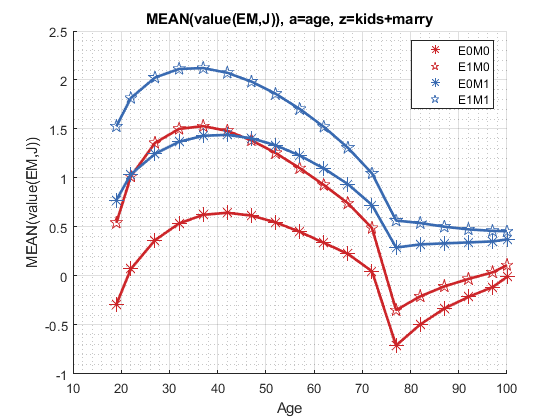

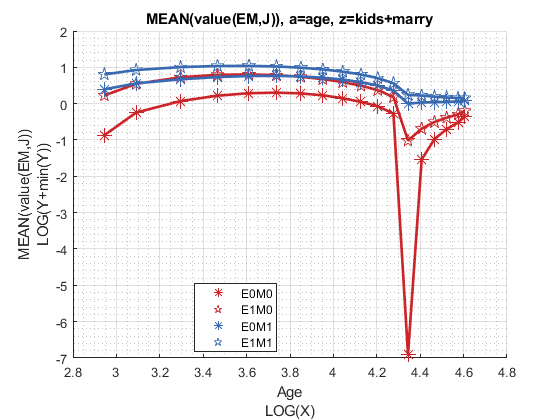

```matlab
mp_support_graph('cl_st_graph_title') = {'MEAN(value(EM,J)), a=age, z=kids+marry'};
mp_support_graph('cl_st_ytitle') = {'MEAN(value(EM,J))'};
ff_graph_grid((tb_az_v{1:end, 4:end}), ar_row_grid, age_grid, mp_support_graph);
```

Graph Mean Savings Choices:

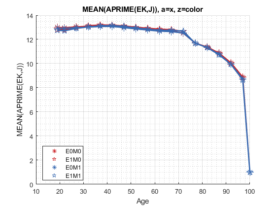

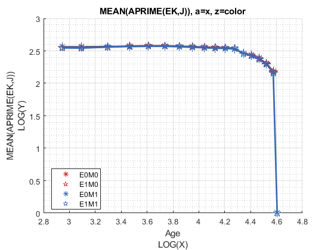

```matlab
mp_support_graph('cl_st_graph_title') = {'MEAN(APRIME(EK,J)), a=x, z=color'};
mp_support_graph('cl_st_ytitle') = {'MEAN(APRIME(EK,J))'};
ff_graph_grid((tb_az_ap{1:end, 4:end}), ar_row_grid, age_grid, mp_support_graph);
```

Graph Mean Consumption:

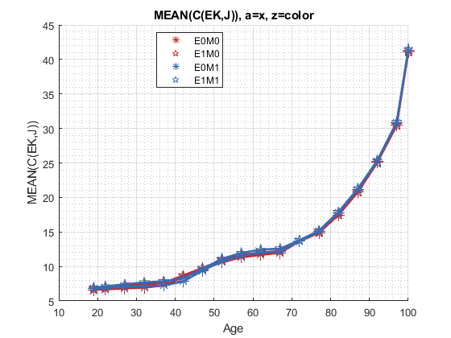

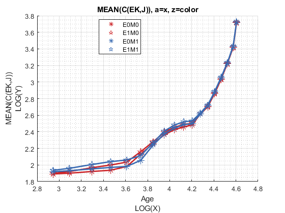

```matlab
mp_support_graph('cl_st_graph_title') = {'MEAN(C(EK,J)), a=x, z=color'};
mp_support_graph('cl_st_ytitle') = {'MEAN(C(EK,J))'};
ff_graph_grid((tb_az_c{1:end, 4:end}), ar_row_grid, age_grid, mp_support_graph);
```